Back to Portfolio

To Capstone Report

# D502 Capstone Analysis

*Project completed by Allysa Grace Fontillas for D502 Data Analytics Capstone | August 09, 2024*

- Introduction
- Research Question/Organizational Need
- Data Preparation
- User Characteristics
- Ride Distribution

## Introduction

This project focuses on analyzing a Ford GoBike dataset that contains information on individual rides that occurred within the Ford GoBike system. The analysis aims to reveal relationships between variables and patterns in the dataset. The insights gained from the analysis could help Ford better understand customer demographics and bike demand, allowing them to make data-driven business decisions.

## Research Question/Organizational Need

The project will address the following research question:

#### What are common characteristics of the consumer base and which variables are associated with demand at the top 10 starting stations?

This question highlights the organizational needs of Ford by providing business leaders insight into the demographics and behaviors of their users. As a result, they can tailor their services to meet specific demands and execute targeted marketing campaigns. Overall, aligning their services with user demand will increase client satisfaction and retention.

## Data Preparation

```python
#Imports the libraries I'll be using
import pandas as pd
import numpy as np
import matplotlib.pyplot as plt
import seaborn as sns
from scipy.stats import chisquare as cs
```

```python
#Loads in the Dataset
df = pd.read_csv('201902-fordgobike-tripdata.csv')
df.head(5)
```

|  | duration_sec | start_time | end_time | start_station_id | start_station_name | start_station_latitude | start_station_longitude | end_station_id | end_station_name | end_station_latitude | end_station_longitude | bike_id | user_type | member_birth_year | member_gender | bike_share_for_all_trip |
| --- | --- | --- | --- | --- | --- | --- | --- | --- | --- | --- | --- | --- | --- | --- | --- | --- |
| 0 | 52185 | 2019-02-28 17:32:10.1450 | 2019-03-01 08:01:55.9750 | 21.0 | Montgomery St BART Station (Market St at 2nd St) | 37.789625 | -122.400811 | 13.0 | Commercial St at Montgomery St | 37.794231 | -122.402923 | 4902 | Customer | 1984.0 | Male | No |
| 1 | 42521 | 2019-02-28 18:53:21.7890 | 2019-03-01 06:42:03.0560 | 23.0 | The Embarcadero at Steuart St | 37.791464 | -122.391034 | 81.0 | Berry St at 4th St | 37.775880 | -122.393170 | 2535 | Customer | NaN | NaN | No |
| 2 | 61854 | 2019-02-28 12:13:13.2180 | 2019-03-01 05:24:08.1460 | 86.0 | Market St at Dolores St | 37.769305 | -122.426826 | 3.0 | Powell St BART Station (Market St at 4th St) | 37.786375 | -122.404904 | 5905 | Customer | 1972.0 | Male | No |
| 3 | 36490 | 2019-02-28 17:54:26.0100 | 2019-03-01 04:02:36.8420 | 375.0 | Grove St at Masonic Ave | 37.774836 | -122.446546 | 70.0 | Central Ave at Fell St | 37.773311 | -122.444293 | 6638 | Subscriber | 1989.0 | Other | No |
| 4 | 1585 | 2019-02-28 23:54:18.5490 | 2019-03-01 00:20:44.0740 | 7.0 | Frank H Ogawa Plaza | 37.804562 | -122.271738 | 222.0 | 10th Ave at E 15th St | 37.792714 | -122.248780 | 4898 | Subscriber | 1974.0 | Male | Yes |

```python
#Returns the number of rows + columns the dataframe has
df.shape
```

```
(183412, 16)
```

```python
df_subset = df[['start_time', 'end_time', 'start_station_name', 'end_station_name', 'user_type', 'member_birth_year', 'member_gender', 'bike_share_for_all_trip']].copy()
df_subset.head(3)
```

|  | start_time | end_time | start_station_name | end_station_name | user_type | member_birth_year | member_gender | bike_share_for_all_trip |
| --- | --- | --- | --- | --- | --- | --- | --- | --- |
| 0 | 2019-02-28 17:32:10.1450 | 2019-03-01 08:01:55.9750 | Montgomery St BART Station (Market St at 2nd St) | Commercial St at Montgomery St | Customer | 1984.0 | Male | No |
| 1 | 2019-02-28 18:53:21.7890 | 2019-03-01 06:42:03.0560 | The Embarcadero at Steuart St | Berry St at 4th St | Customer | NaN | NaN | No |
| 2 | 2019-02-28 12:13:13.2180 | 2019-03-01 05:24:08.1460 | Market St at Dolores St | Powell St BART Station (Market St at 4th St) | Customer | 1972.0 | Male | No |

```python
#Gives a concise summary of the dataframe
df_subset.info()
```

```
<class 'pandas.core.frame.DataFrame'>
RangeIndex: 183412 entries, 0 to 183411
Data columns (total 8 columns):
 #   Column                   Non-Null Count   Dtype
---  ------                   --------------   -----
 0   start_time               183412 non-null  object
 1   end_time                 183412 non-null  object
 2   start_station_name       183215 non-null  object
 3   end_station_name         183215 non-null  object
 4   user_type                183412 non-null  object
 5   member_birth_year        175147 non-null  float64
 6   member_gender            175147 non-null  object
 7   bike_share_for_all_trip  183412 non-null  object
dtypes: float64(1), object(7)
memory usage: 11.2+ MB
```

```python
#Gives summary statistics of the dataframe
df_subset.describe()
```

|  | member_birth_year |
| --- | --- |
| count | 175147.000000 |
| mean | 1984.806437 |
| std | 10.116689 |
| min | 1878.000000 |
| 25% | 1980.000000 |
| 50% | 1987.000000 |
| 75% | 1992.000000 |
| max | 2001.000000 |

### Addressing Outlier `member_birth_years`

According to the [CDC](https://www.cdc.gov/nchs/fastats/life-expectancy.htm), average life expectancy in the U.S is 77.5 Additionally, there is an unexpected value of 1878 and multiple other outliers for `member_birth_year`. Considering the increased risk of comorbidities in the geriatric population, it is highly unlikely that someone over the age of 100 years old would use a bike ride service. As a result, all entries with a `member_birth_year` prior to 1919 will be removed.

```python
#Returns number of rows to be deleted.
ages = df_subset.loc[df_subset['member_birth_year'] < 1919]
ages.shape[0]
```

```
72
```

```python
#Drops birth years >1919
df_subset.drop(ages.index, inplace=True)
```

```python
#Confirms 72 rows dropped (original row count was 183412)
df_subset.shape[0]
```

```
183340
```

### Checking for Duplicates

```python
#Returns sum of duplicate rows
df_subset.duplicated().sum()
```

```
0
```

### Verifying `member_gender` and `member_birth_year` are Expected Values

```python
#Prints all the values for member_gender`
genderValues = df_subset['member_gender'].unique()
print('Gender values in the dataframe:', genderValues)

#Verifies that all birth years end in '.0' or are NaN values prior to converting the column datatype into an integer
yearValues = df_subset['member_birth_year'].unique()
print('Birth year values in the dataframe:', yearValues)
```

```
Gender values in the dataframe: ['Male' nan 'Other' 'Female']
Birth year values in the dataframe: [1984.   nan 1972. 1989. 1974. 1959. 1983. 1988. 1992. 1996. 1993. 1990.
 1981. 1975. 1978. 1991. 1997. 1986. 2000. 1982. 1995. 1980. 1973. 1985.
 1971. 1979. 1967. 1998. 1994. 1977. 1999. 1987. 1969. 1963. 1976. 1964.
 1965. 1961. 1968. 1966. 1962. 1954. 1958. 1960. 1970. 1956. 1957. 1945.
 1952. 1948. 1951. 1941. 1950. 1949. 1953. 1955. 1946. 1947. 1931. 1943.
 1942. 1920. 1933. 2001. 1944. 1928. 1934. 1939. 1930. 1938. 1927.]
```

### Addressing Missing Data

```python
#Drops rows with missing values
#As a reminder: There were only 0.59% missing values in the original csv file
df_subset = df_subset.dropna()
#Prints number of null values for each series
print(df_subset.isnull().sum())
#Prints remaining number of rows + columns
print(df_subset.shape)
```

```
start_time                 0
end_time                   0
start_station_name         0
end_station_name           0
user_type                  0
member_birth_year          0
member_gender              0
bike_share_for_all_trip    0
dtype: int64
(174880, 8)
```

### Converting Data Types

#### Converting `member_birth_year` to Integer

```python
#Converts the birth year column from float to integers
df_subset['member_birth_year'] = df_subset['member_birth_year'].astype('int')
df_subset['member_birth_year']
```

```
0         1984
2         1972
3         1989
4         1974
5         1959
          ...
183407    1996
183408    1984
183409    1990
183410    1988
183411    1989
Name: member_birth_year, Length: 174880, dtype: int32
```

#### Converting `start_time` and `end_time` to Datetime Objects

```python
#Converts start_time and end_time to datetime objects
df_subset['start_time'] = pd.to_datetime(df_subset['start_time'], format='%Y-%m-%d %H:%M:%S.%f', errors='raise')
df_subset['end_time'] = pd.to_datetime(df_subset['end_time'], format='%Y-%m-%d %H:%M:%S.%f', errors='raise')
```

```python
#Gives the min + max of each start_time value and end_time value
print(df_subset['start_time'].min())
print(df_subset['start_time'].max())
print(df_subset['end_time'].min())
print(df_subset['end_time'].max())
```

```
2019-02-01 00:00:20.636000
2019-02-28 23:59:18.548000
2019-02-01 00:04:52.058000
2019-03-01 08:01:55.975000
```

Dataset contains information on bike rides that occured from February 01, 2019 to March 01, 2019.

### Renaming Columns

```python
#Renaming some of the columns for consistency and simplicity
df_subset.rename(columns={'start_time':'start_datetime', 'end_time':'end_datetime', 'member_birth_year':'user_birth_year',
                         'member_gender':'user_gender', 'bike_share_for_all_trip':'bike_share_for_all'}, inplace=True)
```

### Creating Individual Columns to Hold Values for Users' Age, Ride Month, Ride Day, and Ride Time

```python
#Since all of the values in start_time and end_time are in the year 2019, this is the year that will be used to calculate approximate user ages in years.
df_subset['user_age'] = 2019 - df_subset['user_birth_year']

#Creates a column for each detail stored in the start_time and end_time columns
df_subset['start_month'] = df_subset['start_datetime'].dt.strftime('%B')
df_subset['start_day'] = df_subset['start_datetime'].dt.strftime('%A')
df_subset['start_hour'] = df_subset['start_datetime'].dt.strftime('%H')

df_subset['end_month'] = df_subset['end_datetime'].dt.strftime('%B')
df_subset['end_day'] = df_subset['end_datetime'].dt.strftime('%A')
df_subset['end_hour'] = df_subset['end_datetime'].dt.strftime('%H')
```

```python
#Changes all hours from objects -> ints
df_subset['start_hour'] = df_subset['start_hour'].astype('int')
df_subset['end_hour'] = df_subset['end_hour'].astype('int')
```

```python
#Creates a new column called "start_time" that specifies the time of day based on each start_hour
timesOfDay = []
"""
Loop that uses if and elif statements to check the value of `start_hour` and assigns it a value for the new column `start_time`
depending on the `start_hour` value (Hour that the ride starts at)
11PM-4AM Latenight
5AM-11AM Morning
12PM-5PM Afternoon
6-10PM Night
"""
for time in df_subset['start_hour'].iloc[:]:
    #11PM-4AM latenight
    if time <5 or time >= 23:
        timesOfDay.append("Late Night")
    #5AM-11AM morning
    elif time <12:
        timesOfDay.append("Morning")
    #12PM-5PM afternoon
    elif time < 18:
        timesOfDay.append("Afternoon")
    #6PM-10PM night
    elif time <23:
        timesOfDay.append("Night")
df_subset['start_time'] = timesOfDay
```

```python
#Drop redundant columns now that we've acquired individual columns for date and time values.
cleanData = df_subset.drop(columns=['start_datetime', 'end_datetime', 'start_hour', 'end_hour'])

#Preview new dataframe
cleanData.head(1)
```

|  | start_station_name | end_station_name | user_type | user_birth_year | user_gender | bike_share_for_all | user_age | start_month | start_day | end_month | end_day | start_time |
| --- | --- | --- | --- | --- | --- | --- | --- | --- | --- | --- | --- | --- |
| 0 | Montgomery St BART Station (Market St at 2nd St) | Commercial St at Montgomery St | Customer | 1984 | Male | No | 35 | February | Thursday | March | Friday | Afternoon |

### Rearranging the Columns

```python
#Rearranges the columns
cleanData = cleanData.iloc[:,[4, 3, 6, 2, 5, 0, 7, 8, 11, 1, 9, 10]]
cleanData.head(1)
```

|  | user_gender | user_birth_year | user_age | user_type | bike_share_for_all | start_station_name | start_month | start_day | start_time | end_station_name | end_month | end_day |
| --- | --- | --- | --- | --- | --- | --- | --- | --- | --- | --- | --- | --- |
| 0 | Male | 1984 | 35 | Customer | No | Montgomery St BART Station (Market St at 2nd St) | February | Thursday | Afternoon | Commercial St at Montgomery St | March | Friday |

```python
cleanData.describe()
```

|  | user_birth_year | user_age |
| --- | --- | --- |
| count | 174880.000000 | 174880.000000 |
| mean | 1984.837957 | 34.162043 |
| std | 9.974001 | 9.974001 |
| min | 1920.000000 | 18.000000 |
| 25% | 1980.000000 | 27.000000 |
| 50% | 1987.000000 | 32.000000 |
| 75% | 1992.000000 | 39.000000 |
| max | 2001.000000 | 99.000000 |

### Saving Cleaned Data to a .csv File

```python
#Saves the clean file to a CSV just in case
cleanData.to_csv('clean201902_ford.csv', encoding='utf-8', index=False)
```

### Creating a Subset of the Dataframe to Evaluate Ride Demand for the Top 10 Start Stations

```python
cleanData.start_station_name.nunique()
```

```
329
```

```python
#Since there are a total of 329 stations, lets focus on analyzing the top 10 stations bike demand
cleanData.start_station_name.value_counts().head(10)
```

```
start_station_name
Market St at 10th St                                         3649
San Francisco Caltrain Station 2  (Townsend St at 4th St)    3406
Berry St at 4th St                                           2951
Montgomery St BART Station (Market St at 2nd St)             2711
Powell St BART Station (Market St at 4th St)                 2620
San Francisco Caltrain (Townsend St at 4th St)               2572
San Francisco Ferry Building (Harry Bridges Plaza)           2540
Howard St at Beale St                                        2216
Steuart St at Market St                                      2191
Powell St BART Station (Market St at 5th St)                 2144
Name: count, dtype: int64
```

```python
stations = ['Market St at 10th St', 'San Francisco Caltrain Station 2  (Townsend St at 4th St)', 'Berry St at 4th St',
            'Montgomery St BART Station (Market St at 2nd St)', 'Powell St BART Station (Market St at 4th St)', 'San Francisco Caltrain (Townsend St at 4th St)',
            'San Francisco Ferry Building (Harry Bridges Plaza)', 'Howard St at Beale St', 'Steuart St at Market St', 'Powell St BART Station (Market St at 5th St)']

startStations = cleanData.loc[cleanData['start_station_name'].isin(stations)]
```

```python
#Arranges start_day into an ordered categorical datatype
days = ['Sunday', 'Monday', 'Tuesday', 'Wednesday', 'Thursday', 'Friday', 'Saturday']
daysOrdered = pd.CategoricalDtype(ordered=True, categories=days)

#Sets the column start_day to an ordered categorical data type
startStations['start_day'] = startStations['start_day'].astype(daysOrdered)

#Resets the index and drops the old index
startStations.reset_index(drop=True)
```

|  | user_gender | user_birth_year | user_age | user_type | bike_share_for_all | start_station_name | start_month | start_day | start_time | end_station_name | end_month | end_day |
| --- | --- | --- | --- | --- | --- | --- | --- | --- | --- | --- | --- | --- |
| 0 | Male | 1984 | 35 | Customer | No | Montgomery St BART Station (Market St at 2nd St) | February | Thursday | Afternoon | Commercial St at Montgomery St | March | Friday |
| 1 | Female | 1992 | 27 | Subscriber | No | Market St at 10th St | February | Thursday | Late Night | 29th St at Church St | February | Thursday |
| 2 | Male | 1972 | 47 | Subscriber | No | San Francisco Ferry Building (Harry Bridges Pl... | February | Thursday | Late Night | Yerba Buena Center for the Arts (Howard St at ... | February | Thursday |
| 3 | Female | 1990 | 29 | Subscriber | No | Market St at 10th St | February | Thursday | Late Night | Victoria Manalo Draves Park | February | Thursday |
| 4 | Male | 1986 | 33 | Subscriber | No | Montgomery St BART Station (Market St at 2nd St) | February | Thursday | Late Night | Bryant St at 2nd St | February | Thursday |
| ... | ... | ... | ... | ... | ... | ... | ... | ... | ... | ... | ... | ... |
| 26995 | Male | 2000 | 19 | Subscriber | No | Market St at 10th St | February | Friday | Late Night | Valencia St at 22nd St | February | Friday |
| 26996 | Female | 2000 | 19 | Subscriber | No | Market St at 10th St | February | Friday | Late Night | Valencia St at 22nd St | February | Friday |
| 26997 | Female | 2000 | 19 | Subscriber | No | Market St at 10th St | February | Friday | Late Night | Valencia St at 22nd St | February | Friday |
| 26998 | Male | 1993 | 26 | Subscriber | No | San Francisco Caltrain Station 2 (Townsend St... | February | Friday | Late Night | Market St at 10th St | February | Friday |
| 26999 | Male | 1984 | 35 | Subscriber | No | Montgomery St BART Station (Market St at 2nd St) | February | Friday | Late Night | 3rd St at Townsend St | February | Friday |

27000 rows × 12 columns

### Saving the Data Subset to a .csv File

```python
#Saves the clean startStations subset to a CSV file for later use
startStations.to_csv('startStations_fordgobike.csv', encoding='utf-8', index=False)
```

## Data Analysis

### User Characteristics

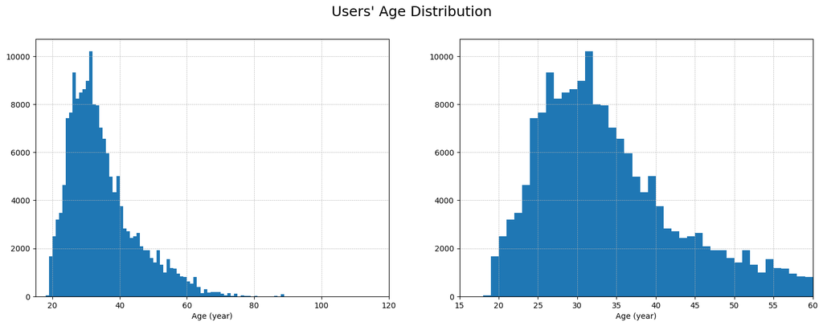

```python
#Setting up the figure for 2 plots side by side
plt.figure(figsize=[18,6])

#Histogram (on the left axis)
plt.subplot(1, 2, 1)
bins= np.arange(0, cleanData['user_age'].max()+1, 1)
plt.hist(data=cleanData, x='user_age', bins=bins);
plt.xlim(15,120);
plt.grid(True, linewidth='.5', linestyle='--')
plt.xlabel('Age (year)');

#Close up (on the right axis)
plt.subplot(1, 2, 2)
plt.hist(data=cleanData, x='user_age', bins=bins);
plt.xlim(15,60);
plt.grid(True, linewidth='.5', linestyle='--')
plt.xlabel('Age (year)');
plt.suptitle("Users' Age Distribution", fontsize=18);
```

The data presents a unimodal structure forming with a rightward skew. There is a higher amount of users who are approximately 26 years old and 31 years old. The minimum age is 18 and the maximum age is 99.

From the graph, we can see that most users in Ford's GoBike system are around 23-40 years old.

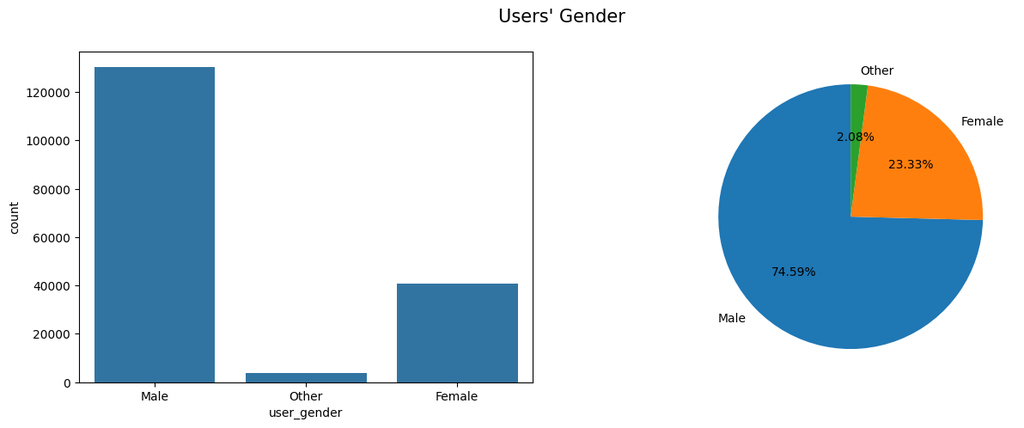

```python
#Setting up the figure for 2 plots side by side
plt.figure(figsize=[15,5])

#Count plot (on the left)
plt.subplot(1, 2, 1)
sns.countplot(data=cleanData, x='user_gender',);

#Pie chart (on the right)
plt.subplot(1, 2, 2)
gendersProp = cleanData['user_gender'].value_counts(normalize=True)
groups = 'Male', 'Female', 'Other'
#Creates my pie chart with the values above and sets it up to displays the values as percentages rounded to the nearest hundredth
plt.pie(gendersProp, labels=groups, autopct='%1.2f%%', startangle=90)
plt.suptitle("Users' Gender", fontsize=15);
plt.show()
```

Approximately 74.59% of the rides in the dataset consist of male users, whereas only 23.33% of rides consist of female users. Less than 2.10% of users identified as "Other".

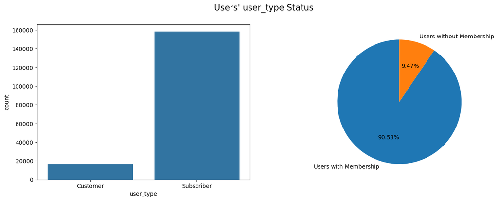

```python
#Setting up the figure for 2 plots side by side
plt.figure(figsize=[15,5])

#Count plot (on the left)
plt.subplot(1, 2, 1)
sns.countplot(data=cleanData, x='user_type',);

#Pie chart (on the right)
plt.subplot(1, 2, 2)
bikeProgram = cleanData['user_type'].value_counts(normalize=True)
groups = 'Users with Membership', 'Users without Membership'
#Creates my pie chart with the values above and sets it up to displays the values as percentages rounded to the nearest hundredth
plt.pie(bikeProgram, labels=groups, autopct='%1.2f%%', startangle=90)
plt.suptitle("Users' user_type Status", fontsize=15);
plt.show()
```

Most users are subscribers (90.53%), there is a small amount of non-subscribers (9.47%).

### Start Station Ride Distribution

#### Ride Distribution in Top 10 Start Stations by Time

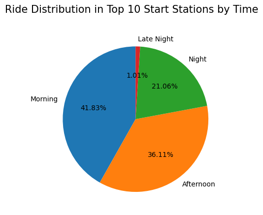

```python
timePeriods = startStations['start_time'].value_counts(normalize=True)
#Creates my pie chart with the values above and sets it up to displays the values as percentages rounded to the nearest hundredth
dayTimes = ['Morning', 'Afternoon', 'Night', 'Late Night']
plt.pie(timePeriods, labels=dayTimes, autopct='%1.2f%%', startangle=90)
plt.suptitle("Ride Distribution in Top 10 Start Stations by Time", fontsize=15);
plt.show()
```

```python
#Arranges start_time into an ordered categorical type
dayTimes = ['Morning', 'Afternoon', 'Night', 'Late Night']
dtOrdered= pd.CategoricalDtype(ordered=True, categories=dayTimes)

#The warning for the line below does not appear to be correct. Even when I change it to the suggested syntax, a warning occurs.
#And when I change it to "startStations.loc['start_time'].astype(daysOrdered)" it will work initially,
#but it does not work when if I restart the kernel and run all cells
startStations['start_time'] = startStations['start_time'].astype(dtOrdered);

#Produces a crosstab or a contingency table to display the frequency distribution of start stations and start_times
ct_stationTimes = pd.crosstab(startStations['start_station_name'], startStations['start_time'])
#Presents the contingency table with color that shades based on frequency
ct_stationTimes.style.background_gradient(axis=None)
```

| start_time start_station_name | Morning | Afternoon | Night | Late Night |
| --- | --- | --- | --- | --- |
| Berry St at 4th St | 1309 | 1133 | 491 | 18 |
| Howard St at Beale St | 1046 | 799 | 361 | 10 |
| Market St at 10th St | 1315 | 1481 | 798 | 55 |
| Montgomery St BART Station (Market St at 2nd St) | 859 | 1245 | 569 | 38 |
| Powell St BART Station (Market St at 4th St) | 664 | 1181 | 741 | 34 |
| Powell St BART Station (Market St at 5th St) | 667 | 838 | 599 | 40 |
| San Francisco Caltrain (Townsend St at 4th St) | 1337 | 704 | 522 | 9 |
| San Francisco Caltrain Station 2 (Townsend St at 4th St) | 1990 | 553 | 829 | 34 |
| San Francisco Ferry Building (Harry Bridges Plaza) | 1132 | 989 | 398 | 21 |
| Steuart St at Market St | 975 | 826 | 377 | 13 |

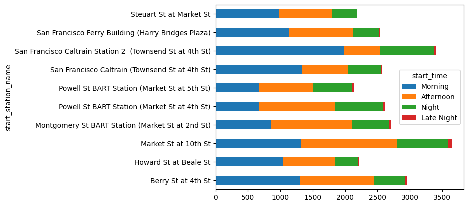

```python
ct_stationTimes.plot.barh(stacked=True);
```

#### Ride Distribution in Top 10 Start Stations by Day

```python
#Produces a crosstab or a contingency table to display the frequency distribution of start stations and start_days
ct_stationDays = pd.crosstab(startStations['start_station_name'], startStations['start_day'])
#Presents the contingency table with color that shades based on frequency
ct_stationDays.style.background_gradient(axis=None)
```

| start_day start_station_name | Sunday | Monday | Tuesday | Wednesday | Thursday | Friday | Saturday |
| --- | --- | --- | --- | --- | --- | --- | --- |
| Berry St at 4th St | 132 | 459 | 568 | 517 | 626 | 511 | 138 |
| Howard St at Beale St | 41 | 353 | 446 | 443 | 490 | 377 | 66 |
| Market St at 10th St | 246 | 501 | 648 | 598 | 714 | 657 | 285 |
| Montgomery St BART Station (Market St at 2nd St) | 91 | 400 | 538 | 499 | 598 | 465 | 120 |
| Powell St BART Station (Market St at 4th St) | 244 | 390 | 439 | 412 | 461 | 404 | 270 |
| Powell St BART Station (Market St at 5th St) | 179 | 343 | 346 | 370 | 413 | 337 | 156 |
| San Francisco Caltrain (Townsend St at 4th St) | 39 | 411 | 558 | 501 | 508 | 510 | 45 |
| San Francisco Caltrain Station 2 (Townsend St at 4th St) | 77 | 574 | 724 | 608 | 801 | 536 | 86 |
| San Francisco Ferry Building (Harry Bridges Plaza) | 134 | 386 | 476 | 431 | 527 | 417 | 169 |
| Steuart St at Market St | 43 | 356 | 458 | 409 | 452 | 401 | 72 |

```python
#Gets the list of stations in the expected order
stations = list(ct_stationDays.index)
```

```python
#Function that queries the count of rides that occurred on each day from each start_station
def obtain():
    sd_info = []
    days = ['Sunday', 'Monday', 'Tuesday', 'Wednesday', 'Thursday', 'Friday', 'Saturday']
    for d in days:
        for s in stations:
            sd_info.append(startStations.query(f"start_station_name == '{s}' and start_day == '{d}'").shape[0])
    return sd_info

#Calls the defined function to put the queries into list sd_items
sd_items = obtain()
```

```python
#Groups each of the gathered counts in sd_items from each station by day
gitems = [sd_items[i:i+10] for i in range (0, len(sd_items), 10)]
gitems
```

```
[[132, 41, 246, 91, 244, 179, 39, 77, 134, 43],
 [459, 353, 501, 400, 390, 343, 411, 574, 386, 356],
 [568, 446, 648, 538, 439, 346, 558, 724, 476, 458],
 [517, 443, 598, 499, 412, 370, 501, 608, 431, 409],
 [626, 490, 714, 598, 461, 413, 508, 801, 527, 452],
 [511, 377, 657, 465, 404, 337, 510, 536, 417, 401],
 [138, 66, 285, 120, 270, 156, 45, 86, 169, 72]]
```

```python
#Uses a chi square test to produce a p-value per station by comparing the demand on each day for a given station
cs(gitems)
```

```
Power_divergenceResult(statistic=array([ 583.53507286,  652.35740072,  401.93587284,  632.66838805,
        112.50610687,  189.70335821,  838.17573872, 1044.60657663,
        379.79370079,  607.46325879]), pvalue=array([8.29831351e-123, 1.17742818e-137, 1.07220957e-083, 2.08839747e-133,
       6.08567962e-022, 2.94208955e-038, 8.67168813e-178, 2.00928954e-222,
       6.15779449e-079, 5.72583889e-128]))
```

All generated p-values are significantly less than the threshold of .05, indicating a statistically significant relationship between the top 10 start stations and days.

```python
#Calculates the expected frequency by taking the total # of rides from each station and dividing it by 7 to find the average over the week
wk_Avgs = ct_stationDays.sum(axis=1)
wk_Avgs = wk_Avgs.apply(lambda x: x/7)
wk_Avgs = list(wk_Avgs.array)
```

```python
#Creates a dataframe to hold observed frequency + expected frequency values
df = pd.DataFrame(gitems, columns = stations)
df.index = days
#Switches columns and rows
df = df.transpose()
#Adds in the expected frequency over a week for each specific station as its own column
df['Expected Freq'] = wk_Avgs

df.head(10)
```

|  | Sunday | Monday | Tuesday | Wednesday | Thursday | Friday | Saturday | Expected Freq |
| --- | --- | --- | --- | --- | --- | --- | --- | --- |
| Berry St at 4th St | 132 | 459 | 568 | 517 | 626 | 511 | 138 | 421.571429 |
| Howard St at Beale St | 41 | 353 | 446 | 443 | 490 | 377 | 66 | 316.571429 |
| Market St at 10th St | 246 | 501 | 648 | 598 | 714 | 657 | 285 | 521.285714 |
| Montgomery St BART Station (Market St at 2nd St) | 91 | 400 | 538 | 499 | 598 | 465 | 120 | 387.285714 |
| Powell St BART Station (Market St at 4th St) | 244 | 390 | 439 | 412 | 461 | 404 | 270 | 374.285714 |
| Powell St BART Station (Market St at 5th St) | 179 | 343 | 346 | 370 | 413 | 337 | 156 | 306.285714 |
| San Francisco Caltrain (Townsend St at 4th St) | 39 | 411 | 558 | 501 | 508 | 510 | 45 | 367.428571 |
| San Francisco Caltrain Station 2 (Townsend St at 4th St) | 77 | 574 | 724 | 608 | 801 | 536 | 86 | 486.571429 |
| San Francisco Ferry Building (Harry Bridges Plaza) | 134 | 386 | 476 | 431 | 527 | 417 | 169 | 362.857143 |
| Steuart St at Market St | 43 | 356 | 458 | 409 | 452 | 401 | 72 | 313.000000 |

```python
#Create the dataframe to be used in the visualization; uses the df dataframe to do so
day_cycle = []
value = []
type = []
station = []
d = []
for day in days:
    d.append(day)
    d.append(day)
for index, row in df.iterrows():
    day_cycle.extend(d)
    for i in range(14):
        station.append(index)
    for day in days:
        type.append("Expected")
        value.append(row['Expected Freq'])
        type.append("Observed")
        value.append(row[day])
new_df = pd.DataFrame({'Station':station,'Day':day_cycle,'Frequency':type,'Value':value})
new_df
```

|  | Station | Day | Frequency | Value |
| --- | --- | --- | --- | --- |
| 0 | Berry St at 4th St | Sunday | Expected | 421.571429 |
| 1 | Berry St at 4th St | Sunday | Observed | 132.000000 |
| 2 | Berry St at 4th St | Monday | Expected | 421.571429 |
| 3 | Berry St at 4th St | Monday | Observed | 459.000000 |
| 4 | Berry St at 4th St | Tuesday | Expected | 421.571429 |
| ... | ... | ... | ... | ... |
| 135 | Steuart St at Market St | Thursday | Observed | 452.000000 |
| 136 | Steuart St at Market St | Friday | Expected | 313.000000 |
| 137 | Steuart St at Market St | Friday | Observed | 401.000000 |
| 138 | Steuart St at Market St | Saturday | Expected | 313.000000 |
| 139 | Steuart St at Market St | Saturday | Observed | 72.000000 |

140 rows × 4 columns

```python
#Saves the created dataframe to a CSV for use in the report
new_df.to_csv('freqofStations.csv', encoding='utf-8', index=False)
```

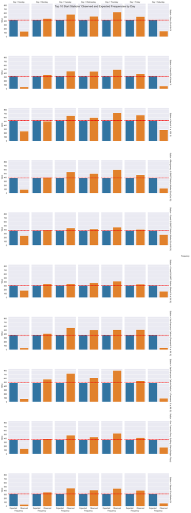

```python
#Plots the observed and expected frequencies of each station for each day
sns.set_style('darkgrid')
g = sns.catplot(new_df,x='Frequency',y='Value', col='Day',row='Station',row_order=stations, hue='Frequency', kind='bar', margin_titles=True, height=4, aspect=.5);
g.fig.suptitle("Top 10 Start Stations' Observed and Expected Frequencies by Day", fontsize=15);

# Function to draw a horizontal line
def hline(*args, **kwargs):
    #Iterates through indexes to get the value of the Expected Frequency
    i=0
    for ax in g.axes.flat:
        ax.axhline(y=new_df.loc[new_df['Frequency']=='Expected', 'Value'].iloc[i], color='red', linestyle='--')
        i+=1
g.map(hline);
```

## Sources:

- [CDC: Life Expectancy](https://www.cdc.gov/nchs/fastats/life-expectancy.htm)
- [Guide for Drawing a Line in FacetGrid](https://www.geeksforgeeks.org/drawing-a-line-at-a-specific-position-and-annotating-a-facetgrid-in-seaborn/)

To Capstone Report